# rangemap short tutorial III

Marlon E. Cobos, Vijay Barve, Narayani Barve, and Alberto Jiménez-Valverde

2018-08-12

## Species distribution ranges based on statistical models

If you haven’t seen the rangemap short tutorial I and II, take a look at them for more background on the **rangemap** R package.

In this example we will explore two functions of this package that allow the users to crate species ranges based on trend surface analyses and ecological niche models.

### Installing or loading the needed packages

```r
# devtools would help us to install rangemap from GitHub
if(!require(devtools)){
  install.packages("devtools")
}

# installing rangemap
if(!require(rangemap)){
  devtools::install_github("marlonecobos/rangemap")
  library(rangemap)
}

# rgibif would help us to get some species occurrence data in our example
if(!require(rgbif)){
  install.packages("rgbif")
  library(rgbif)
}

# maps and maptools will help us to get geographic data for using one of the functions
if(!require(maps)){
install.packages("maps")
library(maps)
}
if(!require(maptools)){
 install.packages("maptools")
 library(maptools)
}

# data from kuenm will be used for using one of the functions
if(!require(kuenm)){
  devtools::install_github("marlonecobos/kuenm")
  library(kuenm)
}
```

### Getting and exploring the species occurrence data

Lest’s first get some data from the GBIF database. Of course you can use your own data instead.

```r
# getting the data from GBIF
species <- name_lookup(query = "Muscigralla brevicauda",
                       rank="species", return = "data") # information about the species

species$key # to see all the keys we can try
```

```
#>  [1] 100183212 104140538 130794317 123216409 133162543 132128393 114073321
#>  [8] 146055371 119251355 102105747 123540848 114143195   2483784 116791457
```

```r
# key 4 was the one with georeferenced occurrences
occ_count(taxonKey = species$key[13], georeferenced = TRUE)
```

```
#> [1] 1147
```

```r
key <- species$key[13] # using species key that return information

occ <- occ_search(taxonKey = key, return = "data", limit = 1200) # using the taxon key

# keeping only species name, and coordinates
occ_g <- occ[!is.na(occ$decimalLatitude) & !is.na(occ$decimalLongitude),
            c("name", "decimalLongitude", "decimalLatitude")]
```

Now let’s see how this species records are geographically distributed using the *rangemap_explore* function.

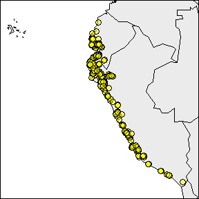

```r
# checking which countries may be involved in the analysis
rangemap_explore(occurrences = occ_g)
```

### Species distribution range usign a trend surface analysis

With the *rangemap_tsa* generates a distributional range for a given species using a trend surface analysis. See the function’s help for more details.

```r
# Defining parameters
## region of interest
WGS84 <- CRS("+proj=longlat +datum=WGS84 +ellps=WGS84 +towgs84=0,0,0") # initial projection
w_map <- map(database = "world", regions = c("ECU", "PER"), fill = TRUE, plot = FALSE) # map
w_po <- sapply(strsplit(w_map$names, ":"), function(x) x[1]) # preparing data to create polygon
reg <- map2SpatialPolygons(w_map, IDs = w_po, proj4string = WGS84) # map to polygon

# All this part is for excluding Galapagos Islands
areas <- lapply(reg@polygons, function(x) sapply(x@Polygons, function(y) y@area))
bigpolys <- unlist(lapply(areas, function(x) which(x > 1)))
reg@polygons[[1]]@Polygons <- reg@polygons[[1]]@Polygons[bigpolys]
reg@polygons[[1]]@plotOrder <- reg@polygons[[1]]@plotOrder[reg@polygons[[1]]@plotOrder %in% bigpolys]
slot(reg, "polygons") <- lapply(slot(reg, "polygons"), "comment<-", NULL)

# Now we can create the species range based a tsa
# Remember, this is a statistical approach, it may take some time depending on the area
thres <- 1 # this argument implies that 1% of the occurrences will be excluded

tsa_range <- rangemap_tsa(occurrences = occ_g, region_of_interest = reg, threshold = thres)
```

**Now the figure of our results**

```r
rangemap_fig(tsa_range, add_occurrences = TRUE, polygons = reg,
             range_color = "transparent")
rangemap_fig(tsa_range, northarrow = TRUE,  polygons = reg,
             legend = TRUE, legend_position = "bottomleft")
```

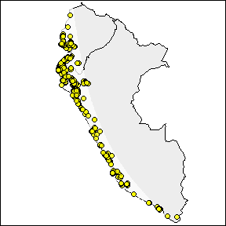

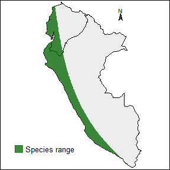

### Species distribution range from an ecological niche model

The function *rangemap_enm* generates a distributional range for a given species using a continuous raster layer produced with an ecological niche modeling algorithm. See the function’s help for more details.

We will borrow a ecological niche model and the occurrences used to create it to create a species range from these data. We will use data from the kuenm package that was loaded at the beginning of this short tutorial. We will try distinct threshold values to see the implications of this parameter in the species ranges.

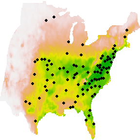

```r
# Getting the data from kuenm
sp_mod <- raster::raster(list.files(system.file("extdata", package = "kuenm"), # model
                                    pattern = "sp_model.tif", full.names = TRUE))
sp_train <- read.csv(list.files(system.file("extdata", package = "kuenm"), # occurrences
                                pattern = "sp_train.csv", full.names = TRUE))

# A rapid look at this data
par(mar = c(0, 0, 0, 0))
raster::image(sp_mod, axes = FALSE, col = rev(terrain.colors(255)))
points(sp_train, pch = 16, cex = 0.8)
```

Now let’s prepare other parameters and run the function.

```r
occ_sp <- data.frame("A_americanum", sp_train) # adding the species name as a first column
thresh <- 1 # threshold 1 to be used
thresh1 <- 5 # threshold 2 to be used
thresh2 <- 10 # threshold 3 to be used

# Now we can create the species range from the models
enm_range <- rangemap_enm(occurrences = occ_sp, model = sp_mod, threshold_omission = thresh)
enm_range1 <- rangemap_enm(occurrences = occ_sp, model = sp_mod, threshold_omission = thresh1)
enm_range2 <- rangemap_enm(occurrences = occ_sp, model = sp_mod, threshold_omission = thresh2)
```

**Seeing all species ranges based on enms**

Using the *rangemap_fig* function we can produce a nice figure for each of the species ranges. Lets put all the figures together and compare them.

```r
rangemap_fig(enm_range, add_occurrences = TRUE, zoom = 2,
             range_color = "transparent")
rangemap_fig(enm_range, zoom = 2)
rangemap_fig(enm_range1, zoom = 2)
rangemap_fig(enm_range2, zoom = 2, legend = TRUE,
             legend_position = c(-6800000, 3500000))
```

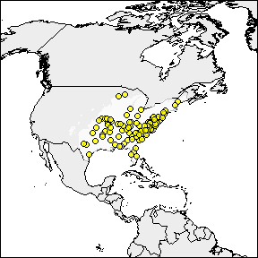

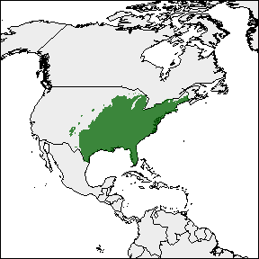

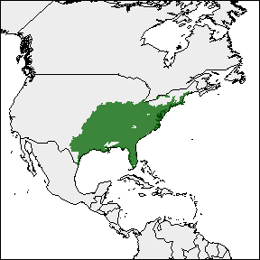

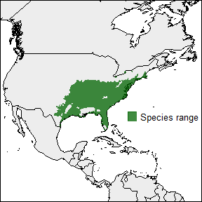